# Reproducible Research: Peer Assessment 1

Markus Friede Hens

Monday, November 03, 2014

## Assumptions

The script assumes that the activity data is present in the current working directory under the name `activity.csv`. The file must contain the folowing features:

| Feature | Type | Description |
| --- | --- | --- |
| steps | int | No. of steps taken |
| date | Date (YYYY-MM-DD) | Date of day |
| interval | int | Interval in day given by date, from 0:00 to 23:55 in 5 minute steps |

### Loading and Preprocessing the data

```r
activitydata <- read.csv("activity.csv", stringsAsFactors = FALSE)
activitydata$date <- as.Date(activitydata$date)
```

### What is the mean total number of steps taken per day?

Aggregate the number of steps per day, based on this mean and median can be easily calculated. `NA`s are ignored.

```r
sumPerDate <- aggregate(activitydata$steps, list(Date = activitydata$date), FUN=sum, na.rm=TRUE)
meanNoOfStepsPerDay <- mean(sumPerDate$x, na.rm=TRUE)
medianNoOfStepsPerDay <- median(sumPerDate$x, na.rm=TRUE)
```

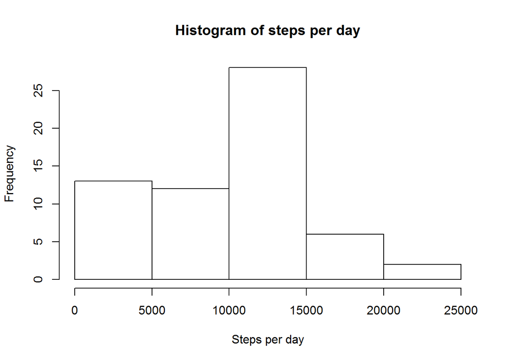

The sample mean is 9354.23 while the sample median is 10395.

### What is the average daily activity pattern?

Calculate the mean per interval. `NA`s are ignored.

```r
meanPerInterval = aggregate(activitydata$steps, list(interval = activitydata$interval), mean, na.rm=TRUE)
```

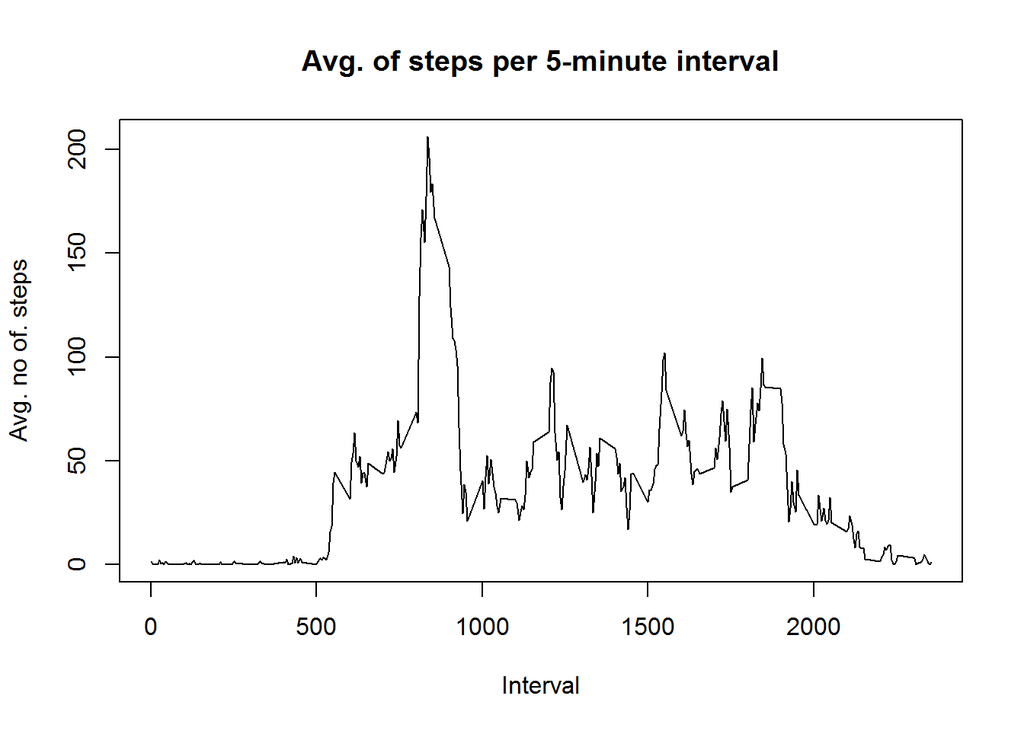

### Imputing missing values

The total number of rows in the data set containing `NA`s is 2304

`NA`s are replaced by the average number of steps for that interval over all days.

```r
activityDataNoNA <- activitydata
rowsWithNA <- which(is.na(activitydata$steps))
activityDataNoNA[rowsWithNA, "steps"] <- round(merge(activitydata[rowsWithNA,], meanPerInterval)$x)
```

Aggregate the number of steps per day, again, this time on the cleaned data set containing no `NA`s, and calculate mean and median again.

```r
sumPerDateNoNA <- aggregate(activityDataNoNA$steps, list(Date = activityDataNoNA$date), FUN=sum)
meanNoOfStepsPerDayNoNA <- mean(sumPerDateNoNA$x)
medianNoOfStepsPerDayNoNA <- median(sumPerDateNoNA$x)
```

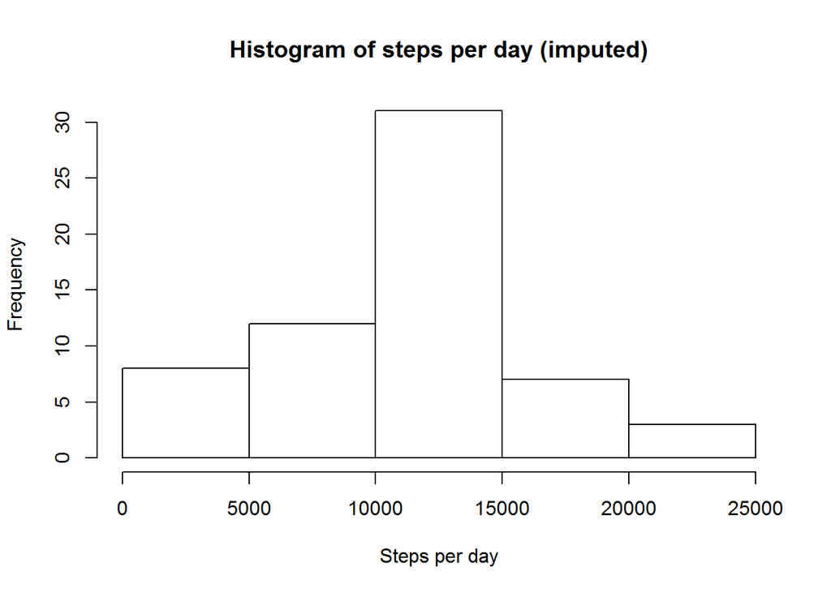

The sample mean of the cleaned data set is 10765.64 while the sample median is 11015. The mean increased by 1411.41, while the median increased by 620.

### Are there differences in activity patterns between weekdays and weekends?

Add information wether a given date is a weekday or not to the data set. Calculate the mean per interval and weekday/weekend on the augmented data set.

```r
weekday <- as.factor(vapply(weekdays(activityDataNoNA$date), FUN=function(x) ifelse(x %in% c("Samstag", "Sonntag"), "weekend", "weekday"), FUN.VALUE="w"))

activityDataNoNA <- cbind(activityDataNoNA, weekday)

meanPerIntervalNoNA = aggregate(activityDataNoNA$steps, list(interval = activityDataNoNA$interval, weekday=activityDataNoNA$weekday), mean)
```

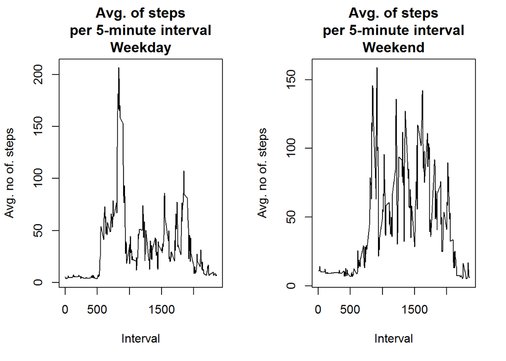